# seoul_crime_analysis

CCTV 데이터 -- https://data.seoul.go.kr/dataList/datasetView.do?infId=OA-2734&srvType=C&serviceKind=1&currentPageNo=1

1. '서울시 자치구 년도별 CCTV 설치 현황(2011년 이전~2018년).xlsx 다운
2. '서울시 CCTV.xlsx'로 저장 & 파일 열기
3. 2018년 컬럼 삭제 & 저장

범죄발생수 데이터 -- https://data.seoul.go.kr/dataList/datasetView.do?infId=316&srvType=S&serviceKind=2

1. 기간 탭에서 년 > 2017년 ~ 2017년으로 설정
2. '자료검색' 클릭, 'XLS' 클릭 & 다운
3. '서울시 범죄빈도.xls'로 저장

여성가구 데이터 -- https://data.seoul.go.kr/dataList/datasetView.do?serviceKind=2&infId=419&srvType=S&stcSrl=419

1. 기간 탭에서 년 > 2017년 ~ 2017년으로 설정
2. '자료검색' 클릭, 'XLS' 클릭 & 다운
3. '서울시 여성인구.xls'로 저장

주요기관 데이터 -- https://data.seoul.go.kr/dataList/datasetView.do?infId=224&srvType=S&serviceKind=2

1. 기간 탭에서 년 > 2017년 ~ 2017년으로 설정
2. '자료검색' 클릭, 'XLS' 클릭 & 다운
3. '서울시 주요기관.xls'로 저장 & 파일 열기
4. 맨 끝에 '합계' 컬럼 생성
5. I2 셀 클릭 > 함수 삽입 아이콘 클릭(fx) > SUM 선택 > Number1 칸에 C2:H2 입력
6. I2 셀을 다시 클릭 > 오른쪽 밑에 커서를 대고 검은색 십자가 모양이 되면 강동구까지 드래그해줌 > 저장

유흥업소 데이터

1. 강남구 -- https://data.seoul.go.kr/dataList/datasetView.do?infId=OA-11281&srvType=S&serviceKind=1&currentPageNo=1
2. 강동구-- https://data.seoul.go.kr/dataList/datasetView.do?infId=OA-10665&srvType=S&serviceKind=1&currentPageNo=1
3. 강북구-- https://data.seoul.go.kr/dataList/datasetView.do?infId=OA-10896&srvType=S&serviceKind=1&currentPageNo=1
4. 강서구-- https://data.seoul.go.kr/dataList/datasetView.do?infId=OA-9972&srvType=S&serviceKind=1&currentPageNo=1
5. 관악구-- https://data.seoul.go.kr/dataList/datasetView.do?infId=OA-11512&srvType=S&serviceKind=1&currentPageNo=1
6. 광진구-- https://data.seoul.go.kr/dataList/datasetView.do?infId=OA-9895&srvType=S&serviceKind=1&currentPageNo=1
7. 구로구-- https://data.seoul.go.kr/dataList/datasetView.do?infId=OA-2308&srvType=S&serviceKind=1&currentPageNo=1
8. 금천구-- https://data.seoul.go.kr/dataList/datasetView.do?infId=OA-10126&srvType=S&serviceKind=1&currentPageNo=1
9. 노원구-- https://data.seoul.go.kr/dataList/datasetView.do?infId=OA-10973&srvType=S&serviceKind=1&currentPageNo=1
10. 도봉구 -- https://data.seoul.go.kr/dataList/datasetView.do?infId=OA-10049&srvType=S&serviceKind=1&currentPageNo=1
11. 동대문구 -- https://data.seoul.go.kr/dataList/datasetView.do?infId=OA-10357&srvType=S&serviceKind=1&currentPageNo=1
12. 동작구 -- https://data.seoul.go.kr/dataList/datasetView.do?infId=OA-10588&srvType=S&serviceKind=1&currentPageNo=1
13. 마포구 -- https://data.seoul.go.kr/dataList/datasetView.do?infId=OA-11358&srvType=S&serviceKind=1&currentPageNo=1
14. 서대문구 -- https://data.seoul.go.kr/dataList/datasetView.do?infId=OA-2345&srvType=S&serviceKind=1&currentPageNo=1
15. 서초구 -- https://data.seoul.go.kr/dataList/datasetView.do?infId=OA-11050&srvType=S&serviceKind=1&currentPageNo=1
16. 성동구 -- https://data.seoul.go.kr/dataList/datasetView.do?infId=OA-10742&srvType=S&serviceKind=1&currentPageNo=1
17. 성북구 -- https://data.seoul.go.kr/dataList/datasetView.do?infId=OA-11127&srvType=S&serviceKind=1&currentPageNo=1
18. 송파구 -- https://data.seoul.go.kr/dataList/datasetView.do?infId=OA-11435&srvType=S&serviceKind=1&currentPageNo=1
19. 양천구 -- https://data.seoul.go.kr/dataList/datasetView.do?infId=OA-10819&srvType=S&serviceKind=1&currentPageNo=1
20. 양등포구 -- https://data.seoul.go.kr/dataList/datasetView.do?infId=OA-10434&srvType=S&serviceKind=1&currentPageNo=1
21. 용산구 -- https://data.seoul.go.kr/dataList/datasetView.do?infId=OA-11204&srvType=S&serviceKind=1&currentPageNo=1
22. 은평구 -- https://data.seoul.go.kr/dataList/datasetView.do?infId=OA-10511&srvType=S&serviceKind=1&currentPageNo=1
23. 종로구 -- https://data.seoul.go.kr/dataList/datasetView.do?infId=OA-9818&srvType=S&serviceKind=1&currentPageNo=1
24. 중구 -- https://data.seoul.go.kr/dataList/datasetView.do?infId=OA-10203&srvType=S&serviceKind=1&currentPageNo=1
25. 중랑구 -- https://data.seoul.go.kr/dataList/datasetView.do?infId=OA-10280&srvType=S&serviceKind=1&currentPageNo=1

(블로그) 서울시 지도 데이터 -- https://raw.githubusercontent.com/southkorea/seoul-maps/master/kostat/2013/json/seoul_municipalities_geo.json

1. 'TL_SCCO_SIG.json' 다운 -- 전국 시군구 데이터
2. 서울시 데이터만 추출하여 다른 파일로 저장 ('서울시 지도.json')

★ 서울시 2017년 후반 데이터로 통일시킴

★ 모듈 설치  
pip install pandas  
pip install numpy  
pip install glob  
pip install warnings  
pip install folium  
pip install tqdm  
pip install geocoder  
pip install paramiko  
pip install xlrd  
pip install xlwt

# CCTV 데이터 정리

|  | 자치구 | CCTV 개수 |
| --- | --- | --- |
| 0 | 강남구 | 4773 |
| 1 | 강동구 | 1494 |
| 2 | 강북구 | 946 |
| 3 | 강서구 | 1363 |
| 4 | 관악구 | 3314 |
| 5 | 광진구 | 1235 |
| 6 | 구로구 | 2741 |
| 7 | 금천구 | 1104 |
| 8 | 노원구 | 1750 |
| 9 | 도봉구 | 787 |
| 10 | 동대문구 | 1806 |
| 11 | 동작구 | 1525 |
| 12 | 마포구 | 1935 |
| 13 | 서대문구 | 1927 |
| 14 | 서초구 | 2439 |
| 15 | 성동구 | 2385 |
| 16 | 성북구 | 2360 |
| 17 | 송파구 | 1190 |
| 18 | 양천구 | 1945 |
| 19 | 영등포구 | 1702 |
| 20 | 용산구 | 2063 |
| 21 | 은평구 | 2595 |
| 22 | 종로구 | 1370 |
| 23 | 중구 | 1216 |
| 24 | 중랑구 | 1059 |

# 범죄빈도수 데이터 정리

|  | 자치구 | 범죄 발생건수 | 범죄 검거건수 |
| --- | --- | --- | --- |
| 23 | 강남구 | 7720 | 5321 |
| 25 | 강동구 | 4261 | 3245 |
| 9 | 강북구 | 3393 | 2824 |
| 16 | 강서구 | 5135 | 3927 |
| 21 | 관악구 | 5525 | 4154 |
| 5 | 광진구 | 4646 | 3289 |
| 17 | 구로구 | 4895 | 3408 |
| 18 | 금천구 | 3265 | 2572 |
| 11 | 노원구 | 4209 | 3047 |
| 10 | 도봉구 | 1999 | 1652 |
| 6 | 동대문구 | 3975 | 3274 |
| 20 | 동작구 | 3330 | 2242 |
| 14 | 마포구 | 5278 | 3499 |
| 13 | 서대문구 | 3113 | 2299 |
| 22 | 서초구 | 4708 | 3237 |
| 4 | 성동구 | 2767 | 2031 |
| 8 | 성북구 | 3434 | 2479 |
| 24 | 송파구 | 5576 | 3870 |
| 15 | 양천구 | 3882 | 2660 |
| 19 | 영등포구 | 5969 | 4012 |
| 3 | 용산구 | 4060 | 2936 |
| 12 | 은평구 | 3883 | 3207 |
| 1 | 종로구 | 4057 | 4437 |
| 2 | 중구 | 4184 | 2851 |
| 7 | 중랑구 | 4571 | 3392 |

# 여성인구 데이터 정리

|  | 자치구 | 여성인구 |
| --- | --- | --- |
| 23 | 강남구 | 292111 |
| 25 | 강동구 | 221660 |
| 9 | 강북구 | 167750 |
| 16 | 강서구 | 312080 |
| 21 | 관악구 | 258923 |
| 5 | 광진구 | 191653 |
| 17 | 구로구 | 220173 |
| 18 | 금천구 | 123716 |
| 11 | 노원구 | 287050 |
| 10 | 도봉구 | 176681 |
| 6 | 동대문구 | 184826 |
| 20 | 동작구 | 209666 |
| 14 | 마포구 | 202535 |
| 13 | 서대문구 | 169778 |
| 22 | 서초구 | 231979 |
| 4 | 성동구 | 158634 |
| 8 | 성북구 | 234304 |
| 24 | 송파구 | 344766 |
| 15 | 양천구 | 240739 |
| 19 | 영등포구 | 199624 |
| 3 | 용산구 | 125021 |
| 12 | 은평구 | 252979 |
| 1 | 종로구 | 84163 |
| 2 | 중구 | 68256 |
| 7 | 중랑구 | 207655 |

# 경찰서/소방서 등의 데이터 정리

|  | 자치구 | 안전관련 공공기관 개수 |
| --- | --- | --- |
| 23 | 강남구 | 32 |
| 25 | 강동구 | 24 |
| 9 | 강북구 | 21 |
| 16 | 강서구 | 19 |
| 21 | 관악구 | 26 |
| 5 | 광진구 | 16 |
| 17 | 구로구 | 25 |
| 18 | 금천구 | 15 |
| 11 | 노원구 | 26 |
| 10 | 도봉구 | 16 |
| 6 | 동대문구 | 28 |
| 20 | 동작구 | 23 |
| 14 | 마포구 | 25 |
| 13 | 서대문구 | 18 |
| 22 | 서초구 | 28 |
| 4 | 성동구 | 21 |
| 8 | 성북구 | 31 |
| 24 | 송파구 | 29 |
| 15 | 양천구 | 24 |
| 19 | 영등포구 | 22 |
| 3 | 용산구 | 19 |
| 12 | 은평구 | 27 |
| 1 | 종로구 | 32 |
| 2 | 중구 | 28 |
| 7 | 중랑구 | 24 |

# 유흥업소 데이터 정리

|  | 자치구 | 유흥업소 개수 |
| --- | --- | --- |
| 0 | 강남구 | 362 |
| 1 | 강동구 | 156 |
| 2 | 강북구 | 84 |
| 3 | 강서구 | 168 |
| 4 | 관악구 | 249 |
| 5 | 광진구 | 21 |
| 6 | 구로구 | 43 |
| 7 | 금천구 | 62 |
| 8 | 노원구 | 33 |
| 9 | 도봉구 | 27 |
| 10 | 동대문구 | 90 |
| 11 | 동작구 | 54 |
| 12 | 마포구 | 69 |
| 13 | 서대문구 | 33 |
| 14 | 서초구 | 96 |
| 15 | 성동구 | 25 |
| 16 | 성북구 | 9 |
| 17 | 송파구 | 134 |
| 18 | 양천구 | 7 |
| 19 | 영등포구 | 186 |
| 20 | 용산구 | 32 |
| 21 | 은평구 | 94 |
| 22 | 종로구 | 225 |
| 23 | 중구 | 268 |
| 24 | 중랑구 | 33 |

# 서울시 지도 그리기 & CCTV 개수에 따라 색 지정

[interactive chart not shown]

# 자치구에 따른 데이터 합치기

# 상관계수

```
array([[1.        , 0.44595531],
       [0.44595531, 1.        ]])
```

# 상관계수에 따른 표 생성

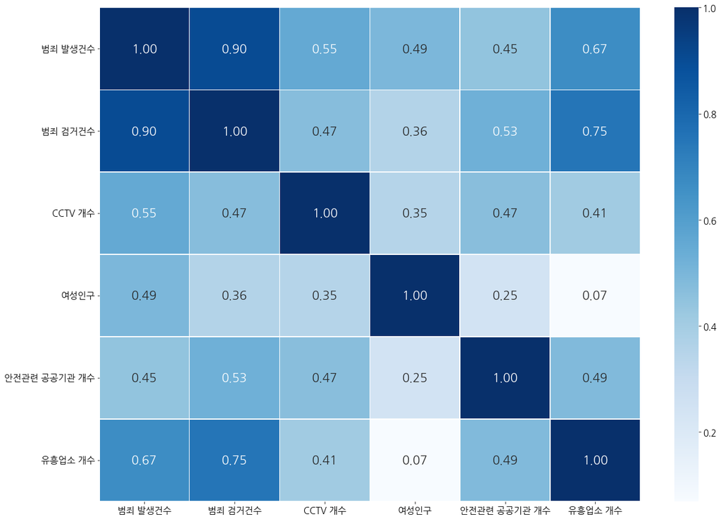

# 구별 범죄 발생건수 그래프

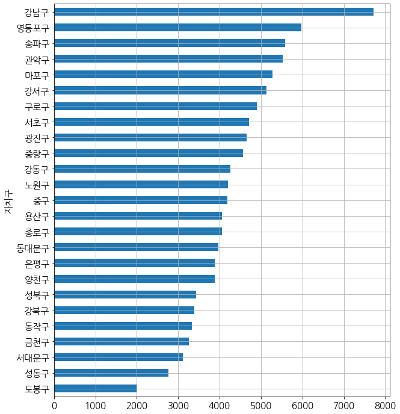

# 범죄 발생건수와 CCTV 개수의 상관관계 그래프

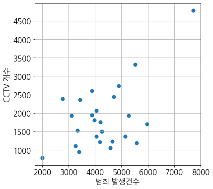

```
array([  0.40764474, 122.62516223])
```

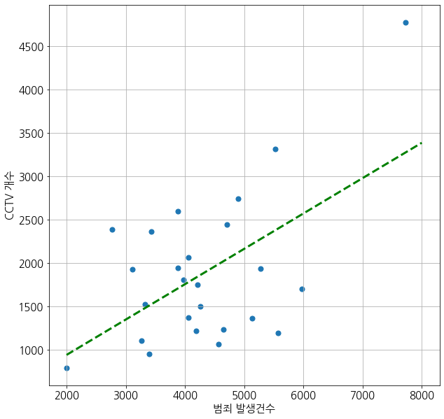

# 범죄 발생건수와 여성인구의 상관관계 그래프

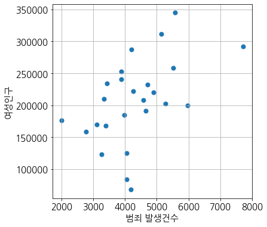

```
array([2.80038000e+01, 8.58772891e+04])
```

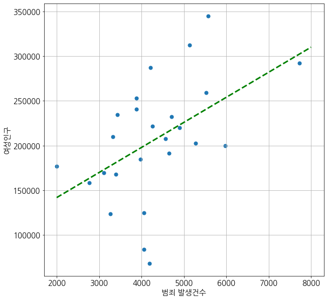

# 범죄 발생건수와 안전관련 공공기관 개수의 상관관계 그래프

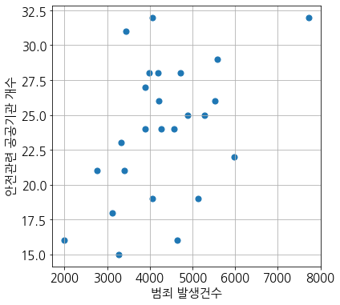

```
array([1.87493514e-03, 1.58726548e+01])
```

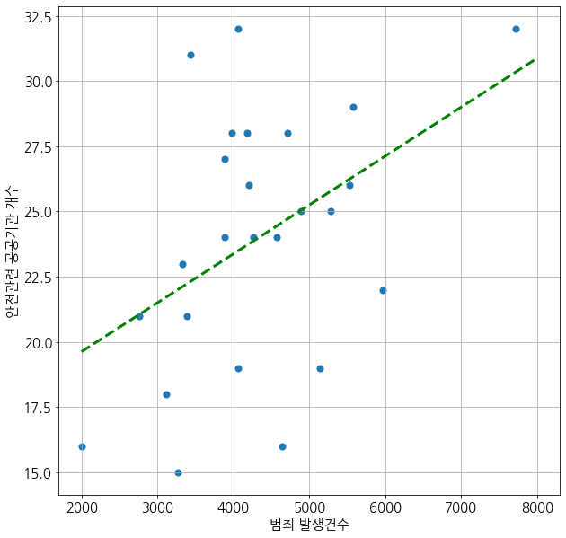

# 범죄 발생건수와 유흥업소 개수의 상관관계 그래프

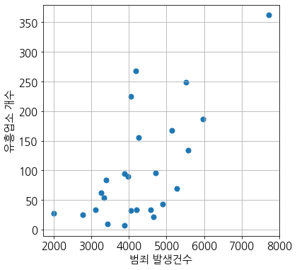

```
array([ 5.31480874e-02, -1.26848960e+02])
```

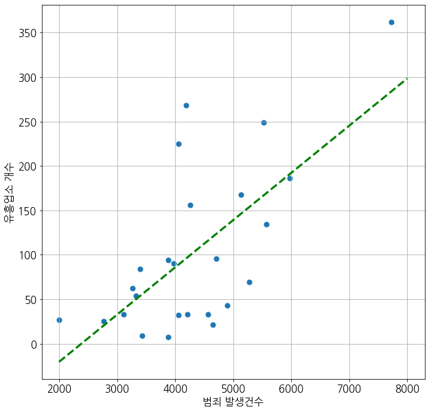

cmd창에 다음을 입력하면 html 파일을 저장해줌  
jupyter nbconvert --to html --TemplateExporter.exclude_input=True seoul_crime_analysis.ipynb